# Part II - (Ford GoBike System Data)

## by (turki alothman)

## Investigation Overview

I am very interested to show the people what factor that make the rider spend more time and what feature that make people rent a bike(what factor will increase the number of individual rides). and my goal to deliver this message at clear as possible.

here some insights that will be included in this file:

- genders can be a factor that increase the number of individual rides.
- most of the individual rides are young people.
- user type(subscriber or customer ) plays a role of individual ride duration.

## Dataset Overview

> This data set includes information about individual rides made in a bike-sharing system covering the greater San Francisco Bay area.

## (Visualization 1)

genders can be a factor that increase the number of individual rides ?

yes!!. Males are the most bike-riding person by a very large margin !!. Then comes the females .This big difference may explain to us that the gender is one of the factors affecting the number of bike rides.

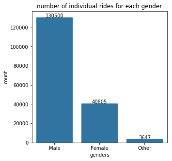

## (Visualization 2)

are most of the individual rides young people ?

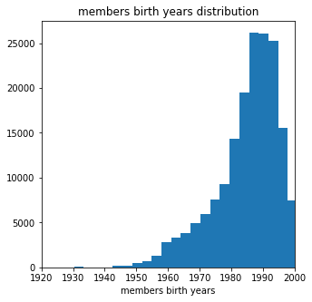

## (Visualization 3)

user type(subscriber or customer ) plays a role of individual ride duration.

yes!! . customers often prefer to take more duration. look at the avarege duration spend .

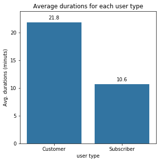